# 2D monod model with deSolve

Chacon

2022-11-03

## two-dimensional simulation of a monod model

This markdown shows how to simulate a simple Monod model in 2D, using deSolve in R.

If you haven’t learned how to do a well-mixed simulation in deSolve, I recommend first looking at the “numerical_ODE_simulation_with_deSolve” protocol.

Generally, the model below can be used as a framework to build reaction-diffusion models (which are partial differential equations models) of any sort.

The “reaction” part is the growth/uptake part of the simulation, and the diffusion is the movement between adjacent boxes.

Here is what the “reaction” part would look like on its own:

```r
# this "inner" model would look something like this:
monod = function(time, state, pars){
  # this is the other way to get variables (as opposed to using named lists)
  # i do it this way here because when we move to 2d, thats how we'll get the data
  ecoli = state[1]
  glucose = state[2]

  with(as.list(pars),{ # still want to just use named parameters
    decoli = ecoli * vmax * glucose / (glucose + km)
    dglucose = -ecoli * vmax * glucose / (glucose + km)

    return(list(c(decoli,dglucose)))
  })
}
```

Now we will put that model in 2D space. We’ll simulate a square that is 5cm X 5cm, divided into 50 boxes on a side.

```r
# now we put that into a 2d space. We'll make a square, 5cm x 5cm, with 50 boxes per side
fullwidth = 5 # cm
N = 50   # boxes
dx = fullwidth/N# boxwidth (cm)
NN = N * N # total # of boxes
```

We will also define the diffusion rates of glucose and ecoli, as this is how these “state variables” will spread between boxes.

```r
# we'll make the resource diffuse at 0.018 cm2/h (=5e-6cm2/s), and the bacteria
# at 1/50th of that
D_glucose = 0.018   # cm2/h, disffusion const (=5e-6 cm2/s)
D_ecoli = D_glucose / 50
```

Now we will make the function which deSolve uses to solve this pde. You may notice that the “reaction” part is basically unchanged from the version above. What has to happen first, though, is convert vectors of ecoli and glucose concentrations to matrices. Then after the reaction part is calculated, the diffusion part is calculated using the matrices. Finally, the matrices are converted back into vectors; this may seem arcane but it is required by deSolve.

Note that in the function definition, in addition to the usual arguments (time, state, pars), we are also explicitly supplying the spatial parameters (N, D_ecoli, D_glucose, dx).

Note that a diffusion calculation on a lattice subtracts 4*the concentration of the focal box, and adds the concentration of each adjacent box, and to make this spatially realistic it does it prortional to the diffusion constant, and to 1/(dx^2). Hopefully this helps explain the diffusion calculations which occur after the reaction.

```r
monod2D <- function (time, state, pars, N, D_ecoli, D_glucose, dx) {
  # this function needs to return a vector of data, not a matrix. That means,
  # each time, the data must be put back into matrix form to do reaction (growth)
  # and diffusion, then put back into vector form. Here we grab the state variables
  # from "state" and separate them into the two different matrices
  NN <- N*N
  ecoli <- matrix(nrow = N, ncol = N,state[1:NN])
  glucose <- matrix(nrow = N, ncol = N,state[(NN+1):(2*NN)])
  # a check, in case of numerical issues. this is good practice for anything which can approach zero, but shouldn't go negative
  # this can happen to the ecoli because of diffusion. it happens to the glucose mostly, because of consumption
  glucose[glucose < 0] = 0
  ecoli[ecoli < 0] = 0

  with (as.list(pars), {
    ## the "reaction" still happens the same way, since the math is vectorized
    decoli_dt = ecoli * vmax * glucose / (glucose + km)
    dglucose_dt = -ecoli * vmax * glucose / (glucose + km)

    # "zero" is a helper deSolve suggested to make calculating diffusion fluxes easier
    zero = rep(0, N)

    # next set of equations does the diffusion calculations

    # if you imagine data like this:   c(1,3,2,4). Focus on the 3. It changes due to
    # diffusion in one axis by adding the data on both sides, then subtracting 2x of the focal.
    # so that "3" changes like:  +1 + 2 -3 -3.  Then, this value is made spatially accurate
    # by multiplying by D/(dx^2)
    #
    # in practice its slightly trickier, because the edges should reflect. We deal
    # with this by adding a copied row above and below before performing that calculation.
    ecoli_rows_bigger = rbind(ecoli[1,], ecoli, ecoli[N,])
    ecoli_rows_diff = ecoli_rows_bigger[1:N,] + ecoli_rows_bigger[3:(N+2),] - 2 * ecoli
    ecoli_rows_diff = D_ecoli * (1 / dx^2) * ecoli_rows_diff

    glucose_rows_bigger = rbind(glucose[1,], glucose, glucose[N,])
    glucose_rows_diff = glucose_rows_bigger[1:N,] + glucose_rows_bigger[3:(N+2),] - 2 * glucose
    glucose_rows_diff = D_glucose * (1 / dx^2) * glucose_rows_diff

    ## Add flux gradient across rows to rate of change, aka add the diffusion to the reaction
    decoli_dt    = decoli_dt + ecoli_rows_diff
    dglucose_dt  = dglucose_dt + glucose_rows_diff

    ## 2. Now repeat, but across columns
    ecoli_cols_bigger = cbind(ecoli[,1], ecoli, ecoli[,N])
    ecoli_cols_diff = ecoli_cols_bigger[,1:N] + ecoli_cols_bigger[,3:(N+2)] - 2 * ecoli
    ecoli_cols_diff = D_ecoli * (1 / dx^2) * ecoli_cols_diff

    glucose_cols_bigger = cbind(glucose[,1], glucose, glucose[,N])
    glucose_cols_diff = glucose_cols_bigger[,1:N] + glucose_cols_bigger[,3:(N+2)] - 2 * glucose
    glucose_cols_diff = D_glucose * (1 / dx^2) * glucose_cols_diff
    ## Add flux gradient across columns to rate of change
    decoli_dt   = decoli_dt + ecoli_cols_diff
    dglucose_dt = dglucose_dt + glucose_cols_diff

    # reconvert the state variables back into vectors, bind them together, and return as list
    return(list(c(as.vector(decoli_dt), as.vector(dglucose_dt))))
  })
}
```

We still set parameters in a named vector.

```r
pars = c(vmax   = 1,    # /hr
             km = 0.01)     # half-saturation constant, [resource]
```

We set the initial conditions SIMILAR to what we do for a well-mixed simulation, but we need NxN initial values for each “layer” (two layers- ecoli and glucose).

We also set the times.

In this example, the glucose will start off uniformly distributed, and ecoli will be rare.

```r
## initial conditions--need NxN for ecoli AND glucose
# get random locs for ecoli, mostly zeros
ecoli_ini = sample(c(rep(0, 125), 1), size = N*N, replace = TRUE)
# uniform resource concentration
glucose_ini = rep(10, N*N)
# all data
yini = c(ecoli_ini, glucose_ini)

# 24 hours
times = seq(0, 24, length.out = 50)
```

Now we solve the model. Note that this uses ode.2D instead of ode.

In this example we’re following deSolve’s suggestion and using a Runge-Kutta based solver. We could swap this out for lsoda, but it may be slower.

NOTE: THIS TAKES ABOUT A MINUTE ON A MODERN (2022) DESKTOP

In the call, notice that we supply “dimens” and “nspec”. The dimens are the spatial dimensions, nspec is how many “layers” (here, 2, one for ecoli, one for glucose). It’s good to tell these to ode2D so it can check you supplied the right number of variables.

Finally, note how we just supply the named spatial parameters. deSolve knows to pass these to the function we supplied (monod2D in this case).

```r
## solve model
# note how we can just supply the named spatial parms
# we also use Cash-Karp Runge-Kutta method for integration cuz its faster than lsoda
#
# this takes about a minute on a 2022 mid-range desktop
out = ode.2D(y = yini, times = times, func = monod2D, parms = pars,
              dimens = c(N, N), nspec = 2, names = c("ecoli", "glucose"),
              N = N, D_ecoli = D_ecoli, D_glucose = D_glucose, dx = dx,
              method = rkMethod("rk45ck"))
```

Good to check some diagnostics:

Note how we did get some data less than zero, hence the importance of the check in the model function.

```r
diagnostics(out)
```

```
##
## --------------------
## rk return code
## --------------------
##
##   return code (idid) =  0
##   Integration was successful.
##
## --------------------
## INTEGER values
## --------------------
##
##   1 The return code : 0
##   2 The number of steps taken for the problem so far: 11034
##   3 The number of function evaluations for the problem so far: 66206
##  13 The number of error test failures of the integrator so far: 284
##  18 The order (or maximum order) of the method: 4
##
```

```r
summary(out)
```

```
##                 ecoli       glucose
## Min.    -7.961180e-43 -5.878922e-05
## 1st Qu.  2.210185e-05  1.210164e-22
## Median   1.017062e+00  1.304640e+00
## Mean     5.929447e+00  4.080553e+00
## 3rd Qu.  9.515273e+00  9.539818e+00
## Max.     6.434654e+01  1.000000e+01
## N        1.250000e+05  1.250000e+05
## sd       8.807748e+00  4.416286e+00
```

Then deSolve has a helper function to grab specific state variables, which it returns as a 3d matrix, with the first two dimensions being x and y, and the third dimension being time. Specifically, the times in “times”.

```r
# use "select" to grab specific state variables. this nicely makes arrays for you
bacteria <- subset(out, select = "ecoli", arr = TRUE)
resource <- subset(out, select = "glucose", arr = TRUE)
```

We can do a simple apply function to sum over time and plot:

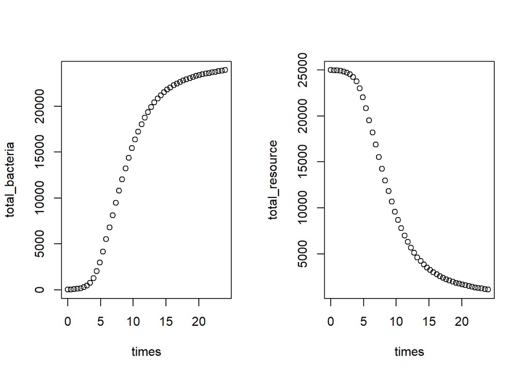

```r
par(mfrow = c(1,2))
# plot totals through time. margin 3 is time (1 = x, 2 = y)
total_bacteria = apply(bacteria, MARGIN = 3, FUN = sum)
total_resource = apply(resource, MARGIN = 3, FUN = sum)
plot(times, total_bacteria)
plot(times, total_resource)
```

We can also plot the actual images from select times. Here I do that in a loop. The top 6 images are ecoli, the bottom six are glucose.

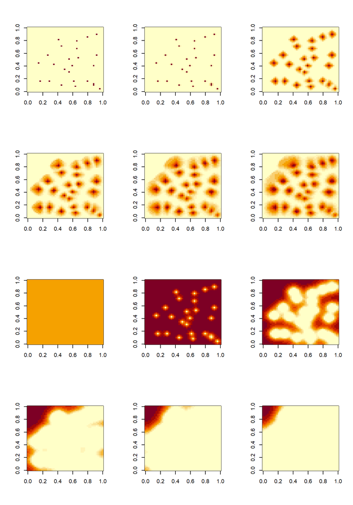

```r
par(mfrow = c(4,3))
for (i in seq(from = 1, to = 50, length.out = 6)){
  image(bacteria[,,i])
}
# and the resource below
for (i in seq(from = 1, to = 50, length.out = 6)){
  image(resource[,,i])
}
```

A final thought:

Back when I did this for the Isme paper, I found that having the diffusion calculations inside the solver sometimes resulted in out-of-memory issues when I was using (large) worlds of 100x100, with three different state variables.

If you run into that, it is pretty straightforward to separate the steps. Then, you still use deSolve for the “reaction” (growth), but just manually do the diffusion calculations. The only real difference here is you multiply by a pre-specified dt, and you run all of this in a loop. Hopefully this isn’t necessary anymore, as it requires a very small dt.